# Case_study_on_Divvy_Bikes

Satyendra

2022-03-28

##Business Task-

Understand how casual riders and annual members of Cyclistic - Bike Share use Cyclistic bikes differently and come up with efficient recommendations to convert casual riders into annual members

##Stakeholders-

1-Lily Moreno - Director of Marketing 2-Cyclistic marketing analytics team 3-Cyclistic executive team

##Ask Phase of Data Analysis

Notes:As it is clear that we want to convert casual members into annual members, we can come up with these SMART questions -

```
*How do annual members and casual riders use Cyclistic bikes differently?
*Why would casual riders buy Cyclistic annual memberships?
*How can Cyclistic use digital media to influence casual riders to become       members?
```

#key Question “In what ways do members and casual riders use Divvy bikes differently?”

## Setting up the environment

Notes:Importing required libraries

```r
library(tidyverse)
```

```r
library(ggplot2)
```

```r
library(lubridate) # for time and date
```

## Importing the dataset of Divvy bikes for year 2021

Notes: Data of every month

```r
mon_jan<-read.csv("D:\\google cert\\case\\zip files\\unzip files\\202101-divvy-tripdata.csv")
```

```r
mon_feb<-read.csv("D:\\google cert\\case\\zip files\\unzip files\\202102-divvy-tripdata.csv")
```

```r
mon_march<-read.csv("D:\\google cert\\case\\zip files\\unzip files\\202103-divvy-tripdata.csv")
```

```r
mon_april<-read.csv("D:\\google cert\\case\\zip files\\unzip files\\202104-divvy-tripdata.csv")
```

```r
mon_may<-read.csv("D:\\google cert\\case\\zip files\\unzip files\\202105-divvy-tripdata.csv")
```

```r
mon_june<-read.csv("D:\\google cert\\case\\zip files\\unzip files\\202106-divvy-tripdata.csv")
```

```r
mon_july<-read.csv("D:\\google cert\\case\\zip files\\unzip files\\202107-divvy-tripdata.csv")
```

```r
mon_aug<-read.csv("D:\\google cert\\case\\zip files\\unzip files\\202108-divvy-tripdata.csv")
```

```r
mon_sept<-read.csv("D:\\google cert\\case\\zip files\\unzip files\\202109-divvy-tripdata.csv")
```

```r
mon_oct<-read.csv("D:\\google cert\\case\\zip files\\unzip files\\202110-divvy-tripdata.csv")
```

```r
mon_nov<-read.csv("D:\\google cert\\case\\zip files\\unzip files\\202111-divvy-tripdata.csv")
```

```r
mon_dec<-read.csv("D:\\google cert\\case\\zip files\\unzip files\\202112-divvy-tripdata.csv")
```

## Getting glimpse of column names of data

```r
colnames(mon_jan)
```

```
##  [1] "ride_id"            "rideable_type"      "started_at"
##  [4] "ended_at"           "start_station_name" "start_station_id"
##  [7] "end_station_name"   "end_station_id"     "start_lat"
## [10] "start_lng"          "end_lat"            "end_lng"
## [13] "member_casual"
```

Notes:Every month has same no of columns

```r
colnames(mon_july)
```

```
##  [1] "ride_id"            "rideable_type"      "started_at"
##  [4] "ended_at"           "start_station_name" "start_station_id"
##  [7] "end_station_name"   "end_station_id"     "start_lat"
## [10] "start_lng"          "end_lat"            "end_lng"
## [13] "member_casual"
```

```r
colnames(mon_dec)
```

```
##  [1] "ride_id"            "rideable_type"      "started_at"
##  [4] "ended_at"           "start_station_name" "start_station_id"
##  [7] "end_station_name"   "end_station_id"     "start_lat"
## [10] "start_lng"          "end_lat"            "end_lng"
## [13] "member_casual"
```

##Understanding the structure of data -for January month(similar to each month)

```r
str(mon_jan)
```

```
## 'data.frame':    96834 obs. of  13 variables:
##  $ ride_id           : chr  "E19E6F1B8D4C42ED" "DC88F20C2C55F27F" "EC45C94683FE3F27" "4FA453A75AE377DB" ...
##  $ rideable_type     : chr  "electric_bike" "electric_bike" "electric_bike" "electric_bike" ...
##  $ started_at        : chr  "2021-01-23 16:14:19" "2021-01-27 18:43:08" "2021-01-21 22:35:54" "2021-01-07 13:31:13" ...
##  $ ended_at          : chr  "2021-01-23 16:24:44" "2021-01-27 18:47:12" "2021-01-21 22:37:14" "2021-01-07 13:42:55" ...
##  $ start_station_name: chr  "California Ave & Cortez St" "California Ave & Cortez St" "California Ave & Cortez St" "California Ave & Cortez St" ...
##  $ start_station_id  : chr  "17660" "17660" "17660" "17660" ...
##  $ end_station_name  : chr  "" "" "" "" ...
##  $ end_station_id    : chr  "" "" "" "" ...
##  $ start_lat         : num  41.9 41.9 41.9 41.9 41.9 ...
##  $ start_lng         : num  -87.7 -87.7 -87.7 -87.7 -87.7 ...
##  $ end_lat           : num  41.9 41.9 41.9 41.9 41.9 ...
##  $ end_lng           : num  -87.7 -87.7 -87.7 -87.7 -87.7 ...
##  $ member_casual     : chr  "member" "member" "member" "member" ...
```

###feb montth

```r
str(mon_feb)
```

```
## 'data.frame':    49622 obs. of  13 variables:
##  $ ride_id           : chr  "89E7AA6C29227EFF" "0FEFDE2603568365" "E6159D746B2DBB91" "B32D3199F1C2E75B" ...
##  $ rideable_type     : chr  "classic_bike" "classic_bike" "electric_bike" "classic_bike" ...
##  $ started_at        : chr  "2021-02-12 16:14:56" "2021-02-14 17:52:38" "2021-02-09 19:10:18" "2021-02-02 17:49:41" ...
##  $ ended_at          : chr  "2021-02-12 16:21:43" "2021-02-14 18:12:09" "2021-02-09 19:19:10" "2021-02-02 17:54:06" ...
##  $ start_station_name: chr  "Glenwood Ave & Touhy Ave" "Glenwood Ave & Touhy Ave" "Clark St & Lake St" "Wood St & Chicago Ave" ...
##  $ start_station_id  : chr  "525" "525" "KA1503000012" "637" ...
##  $ end_station_name  : chr  "Sheridan Rd & Columbia Ave" "Bosworth Ave & Howard St" "State St & Randolph St" "Honore St & Division St" ...
##  $ end_station_id    : chr  "660" "16806" "TA1305000029" "TA1305000034" ...
##  $ start_lat         : num  42 42 41.9 41.9 41.8 ...
##  $ start_lng         : num  -87.7 -87.7 -87.6 -87.7 -87.6 ...
##  $ end_lat           : num  42 42 41.9 41.9 41.8 ...
##  $ end_lng           : num  -87.7 -87.7 -87.6 -87.7 -87.6 ...
##  $ member_casual     : chr  "member" "casual" "member" "member" ...
```

```r
str(mon_july)
```

```
## 'data.frame':    822410 obs. of  13 variables:
##  $ ride_id           : chr  "0A1B623926EF4E16" "B2D5583A5A5E76EE" "6F264597DDBF427A" "379B58EAB20E8AA5" ...
##  $ rideable_type     : chr  "docked_bike" "classic_bike" "classic_bike" "classic_bike" ...
##  $ started_at        : chr  "2021-07-02 14:44:36" "2021-07-07 16:57:42" "2021-07-25 11:30:55" "2021-07-08 22:08:30" ...
##  $ ended_at          : chr  "2021-07-02 15:19:58" "2021-07-07 17:16:09" "2021-07-25 11:48:45" "2021-07-08 22:23:32" ...
##  $ start_station_name: chr  "Michigan Ave & Washington St" "California Ave & Cortez St" "Wabash Ave & 16th St" "California Ave & Cortez St" ...
##  $ start_station_id  : chr  "13001" "17660" "SL-012" "17660" ...
##  $ end_station_name  : chr  "Halsted St & North Branch St" "Wood St & Hubbard St" "Rush St & Hubbard St" "Carpenter St & Huron St" ...
##  $ end_station_id    : chr  "KA1504000117" "13432" "KA1503000044" "13196" ...
##  $ start_lat         : num  41.9 41.9 41.9 41.9 41.9 ...
##  $ start_lng         : num  -87.6 -87.7 -87.6 -87.7 -87.7 ...
##  $ end_lat           : num  41.9 41.9 41.9 41.9 41.9 ...
##  $ end_lng           : num  -87.6 -87.7 -87.6 -87.7 -87.7 ...
##  $ member_casual     : chr  "casual" "casual" "member" "member" ...
```

```r
str(mon_dec)
```

```
## 'data.frame':    247540 obs. of  13 variables:
##  $ ride_id           : chr  "46F8167220E4431F" "73A77762838B32FD" "4CF42452054F59C5" "3278BA87BF698339" ...
##  $ rideable_type     : chr  "electric_bike" "electric_bike" "electric_bike" "classic_bike" ...
##  $ started_at        : chr  "2021-12-07 15:06:07" "2021-12-11 03:43:29" "2021-12-15 23:10:28" "2021-12-26 16:16:10" ...
##  $ ended_at          : chr  "2021-12-07 15:13:42" "2021-12-11 04:10:23" "2021-12-15 23:23:14" "2021-12-26 16:30:53" ...
##  $ start_station_name: chr  "Laflin St & Cullerton St" "LaSalle Dr & Huron St" "Halsted St & North Branch St" "Halsted St & North Branch St" ...
##  $ start_station_id  : chr  "13307" "KP1705001026" "KA1504000117" "KA1504000117" ...
##  $ end_station_name  : chr  "Morgan St & Polk St" "Clarendon Ave & Leland Ave" "Broadway & Barry Ave" "LaSalle Dr & Huron St" ...
##  $ end_station_id    : chr  "TA1307000130" "TA1307000119" "13137" "KP1705001026" ...
##  $ start_lat         : num  41.9 41.9 41.9 41.9 41.9 ...
##  $ start_lng         : num  -87.7 -87.6 -87.6 -87.6 -87.7 ...
##  $ end_lat           : num  41.9 42 41.9 41.9 41.9 ...
##  $ end_lng           : num  -87.7 -87.7 -87.6 -87.6 -87.6 ...
##  $ member_casual     : chr  "member" "casual" "member" "member" ...
```

## Making changes in data types of specific columns of each month

```r
mon_jan<-  mutate(mon_jan, start_station_id = as.character(start_station_id)
                      ,end_station_id = as.character(end_station_id))
```

```r
mon_feb<-  mutate(mon_feb, start_station_id = as.character(start_station_id)
                      ,end_station_id = as.character(end_station_id))
```

```r
mon_march<-mutate(mon_march, start_station_id = as.character(start_station_id)
                      ,end_station_id = as.character(end_station_id))
```

```r
mon_april<-mutate(mon_april, start_station_id = as.character(start_station_id)
                      ,end_station_id = as.character(end_station_id))
```

```r
mon_may<-mutate(mon_may, start_station_id = as.character(start_station_id)
                      ,end_station_id = as.character(end_station_id))
```

```r
mon_june<-  mutate(mon_june, start_station_id = as.character(start_station_id)
                      ,end_station_id = as.character(end_station_id))
```

```r
mon_july<-  mutate(mon_july, start_station_id = as.character(start_station_id)
                      ,end_station_id = as.character(end_station_id))
```

```r
mon_aug<-  mutate(mon_aug, start_station_id = as.character(start_station_id)
                      ,end_station_id = as.character(end_station_id))
```

```r
mon_sept<-  mutate(mon_sept, start_station_id = as.character(start_station_id)
                      ,end_station_id = as.character(end_station_id))
```

```r
mon_oct<-  mutate(mon_oct, start_station_id = as.character(start_station_id)
                      ,end_station_id = as.character(end_station_id))
```

```r
mon_nov<-  mutate(mon_nov, start_station_id = as.character(start_station_id)
                      ,end_station_id = as.character(end_station_id))
```

```r
mon_dec<-  mutate(mon_dec, start_station_id = as.character(start_station_id)
                      ,end_station_id = as.character(end_station_id))
```

#Combining all month data into a single dataset

```r
trips<-bind_rows(mon_jan,mon_feb,mon_march,mon_april,mon_may,mon_june,mon_july,mon_aug,mon_sept,mon_oct,mon_nov,mon_dec)
```

```r
str(trips)
```

```
## 'data.frame':    5595063 obs. of  13 variables:
##  $ ride_id           : chr  "E19E6F1B8D4C42ED" "DC88F20C2C55F27F" "EC45C94683FE3F27" "4FA453A75AE377DB" ...
##  $ rideable_type     : chr  "electric_bike" "electric_bike" "electric_bike" "electric_bike" ...
##  $ started_at        : chr  "2021-01-23 16:14:19" "2021-01-27 18:43:08" "2021-01-21 22:35:54" "2021-01-07 13:31:13" ...
##  $ ended_at          : chr  "2021-01-23 16:24:44" "2021-01-27 18:47:12" "2021-01-21 22:37:14" "2021-01-07 13:42:55" ...
##  $ start_station_name: chr  "California Ave & Cortez St" "California Ave & Cortez St" "California Ave & Cortez St" "California Ave & Cortez St" ...
##  $ start_station_id  : chr  "17660" "17660" "17660" "17660" ...
##  $ end_station_name  : chr  "" "" "" "" ...
##  $ end_station_id    : chr  "" "" "" "" ...
##  $ start_lat         : num  41.9 41.9 41.9 41.9 41.9 ...
##  $ start_lng         : num  -87.7 -87.7 -87.7 -87.7 -87.7 ...
##  $ end_lat           : num  41.9 41.9 41.9 41.9 41.9 ...
##  $ end_lng           : num  -87.7 -87.7 -87.7 -87.7 -87.7 ...
##  $ member_casual     : chr  "member" "member" "member" "member" ...
```

# DATA CLEANING

Notes :dropping column of no use

```r
trips<-trips %>%
  select(-c(start_lat,start_lng,end_lat,end_lng))
str(trips)
```

```
## 'data.frame':    5595063 obs. of  9 variables:
##  $ ride_id           : chr  "E19E6F1B8D4C42ED" "DC88F20C2C55F27F" "EC45C94683FE3F27" "4FA453A75AE377DB" ...
##  $ rideable_type     : chr  "electric_bike" "electric_bike" "electric_bike" "electric_bike" ...
##  $ started_at        : chr  "2021-01-23 16:14:19" "2021-01-27 18:43:08" "2021-01-21 22:35:54" "2021-01-07 13:31:13" ...
##  $ ended_at          : chr  "2021-01-23 16:24:44" "2021-01-27 18:47:12" "2021-01-21 22:37:14" "2021-01-07 13:42:55" ...
##  $ start_station_name: chr  "California Ave & Cortez St" "California Ave & Cortez St" "California Ave & Cortez St" "California Ave & Cortez St" ...
##  $ start_station_id  : chr  "17660" "17660" "17660" "17660" ...
##  $ end_station_name  : chr  "" "" "" "" ...
##  $ end_station_id    : chr  "" "" "" "" ...
##  $ member_casual     : chr  "member" "member" "member" "member" ...
```

Notes:Details of Members of Divvy Bikes

```r
table(trips$member_casual)
```

```
##
##  casual  member
## 2529005 3066058
```

Notes: Changing names from casual to “customer” and memeber to “Subscriber”

```r
trips<-trips %>%
  mutate(member_casual=recode(member_casual,
                              "member"="Subscriber","casual"="Customer"))
str(trips)
```

```
## 'data.frame':    5595063 obs. of  9 variables:
##  $ ride_id           : chr  "E19E6F1B8D4C42ED" "DC88F20C2C55F27F" "EC45C94683FE3F27" "4FA453A75AE377DB" ...
##  $ rideable_type     : chr  "electric_bike" "electric_bike" "electric_bike" "electric_bike" ...
##  $ started_at        : chr  "2021-01-23 16:14:19" "2021-01-27 18:43:08" "2021-01-21 22:35:54" "2021-01-07 13:31:13" ...
##  $ ended_at          : chr  "2021-01-23 16:24:44" "2021-01-27 18:47:12" "2021-01-21 22:37:14" "2021-01-07 13:42:55" ...
##  $ start_station_name: chr  "California Ave & Cortez St" "California Ave & Cortez St" "California Ave & Cortez St" "California Ave & Cortez St" ...
##  $ start_station_id  : chr  "17660" "17660" "17660" "17660" ...
##  $ end_station_name  : chr  "" "" "" "" ...
##  $ end_station_id    : chr  "" "" "" "" ...
##  $ member_casual     : chr  "Subscriber" "Subscriber" "Subscriber" "Subscriber" ...
```

```r
table(trips$member_casual) # total no of customers of particular type
```

```
##
##   Customer Subscriber
##    2529005    3066058
```

##Getting Glimpse of modified data

```r
colnames(trips)
```

```
## [1] "ride_id"            "rideable_type"      "started_at"
## [4] "ended_at"           "start_station_name" "start_station_id"
## [7] "end_station_name"   "end_station_id"     "member_casual"
```

```r
nrow(trips) # no of rows in complete data set
```

```
## [1] 5595063
```

```r
dim(trips) #dimension of combined data set
```

```
## [1] 5595063       9
```

```r
head(trips) # head rows of trips dataset
```

```
##            ride_id rideable_type          started_at            ended_at
## 1 E19E6F1B8D4C42ED electric_bike 2021-01-23 16:14:19 2021-01-23 16:24:44
## 2 DC88F20C2C55F27F electric_bike 2021-01-27 18:43:08 2021-01-27 18:47:12
## 3 EC45C94683FE3F27 electric_bike 2021-01-21 22:35:54 2021-01-21 22:37:14
## 4 4FA453A75AE377DB electric_bike 2021-01-07 13:31:13 2021-01-07 13:42:55
## 5 BE5E8EB4E7263A0B electric_bike 2021-01-23 02:24:02 2021-01-23 02:24:45
## 6 5D8969F88C773979 electric_bike 2021-01-09 14:24:07 2021-01-09 15:17:54
##           start_station_name start_station_id end_station_name end_station_id
## 1 California Ave & Cortez St            17660
## 2 California Ave & Cortez St            17660
## 3 California Ave & Cortez St            17660
## 4 California Ave & Cortez St            17660
## 5 California Ave & Cortez St            17660
## 6 California Ave & Cortez St            17660
##   member_casual
## 1    Subscriber
## 2    Subscriber
## 3    Subscriber
## 4    Subscriber
## 5      Customer
## 6      Customer
```

```r
summary(trips) #generating summary
```

```
##    ride_id          rideable_type       started_at          ended_at
##  Length:5595063     Length:5595063     Length:5595063     Length:5595063
##  Class :character   Class :character   Class :character   Class :character
##  Mode  :character   Mode  :character   Mode  :character   Mode  :character
##  start_station_name start_station_id   end_station_name   end_station_id
##  Length:5595063     Length:5595063     Length:5595063     Length:5595063
##  Class :character   Class :character   Class :character   Class :character
##  Mode  :character   Mode  :character   Mode  :character   Mode  :character
##  member_casual
##  Length:5595063
##  Class :character
##  Mode  :character
```

##Adding new columns

```r
trips$date<-as.Date(trips$started_at) #extracting date from started date column format yyyy-mm-dd
```

```r
trips$month<-format(as.Date(trips$date),"%m") #extracting month from date column
```

```r
trips$day <- format(as.Date(trips$date), "%d")#extracting day from date
```

```r
trips$year <- format(as.Date(trips$date), "%Y")#extracting year from date
```

```r
trips$day_of_week <-format(as.Date(trips$date),"%A")#extracting day of week from date
```

##Calculating ride length of each customer for our analysis

```r
trips$ride_length<-difftime(trips$ended_at,trips$started_at) #ended_at and started_at columns difference give ride length of the rider in seconds
```

```r
head(trips,5)
```

```
##            ride_id rideable_type          started_at            ended_at
## 1 E19E6F1B8D4C42ED electric_bike 2021-01-23 16:14:19 2021-01-23 16:24:44
## 2 DC88F20C2C55F27F electric_bike 2021-01-27 18:43:08 2021-01-27 18:47:12
## 3 EC45C94683FE3F27 electric_bike 2021-01-21 22:35:54 2021-01-21 22:37:14
## 4 4FA453A75AE377DB electric_bike 2021-01-07 13:31:13 2021-01-07 13:42:55
## 5 BE5E8EB4E7263A0B electric_bike 2021-01-23 02:24:02 2021-01-23 02:24:45
##           start_station_name start_station_id end_station_name end_station_id
## 1 California Ave & Cortez St            17660
## 2 California Ave & Cortez St            17660
## 3 California Ave & Cortez St            17660
## 4 California Ave & Cortez St            17660
## 5 California Ave & Cortez St            17660
##   member_casual       date month day year day_of_week ride_length
## 1    Subscriber 2021-01-23    01  23 2021    Saturday    625 secs
## 2    Subscriber 2021-01-27    01  27 2021   Wednesday    244 secs
## 3    Subscriber 2021-01-21    01  21 2021    Thursday     80 secs
## 4    Subscriber 2021-01-07    01  07 2021    Thursday    702 secs
## 5      Customer 2021-01-23    01  23 2021    Saturday     43 secs
```

Notes:Changing type of ride_length column

```r
is.factor(trips$ride_length)
```

```
## [1] FALSE
```

```r
trips$ride_length <- as.numeric(as.character(trips$ride_length))
```

#Analytical phase ##Generating summary with respect to ride_length column

```r
summary(trips$ride_length)
```

```
##    Min. 1st Qu.  Median    Mean 3rd Qu.    Max.
##   -3482     405     720    1316    1307 3356649
```

Notes:since negative values are present so we remove them

```r
trips_v2 <- trips[!(trips$start_station_name == "HQ QR" | trips$ride_length<0),]
```

##Generating summary again

```r
summary(trips$ride_length)
```

```
##    Min. 1st Qu.  Median    Mean 3rd Qu.    Max.
##   -3482     405     720    1316    1307 3356649
```

Notes:Mean of ride length with respect to membership status

```r
aggregate(trips_v2$ride_length ~ trips_v2$member_casual, FUN = mean)
```

```
##   trips_v2$member_casual trips_v2$ride_length
## 1               Customer            1920.1327
## 2             Subscriber             818.0129
```

Notes:Median of ride length with respect to membership status

```r
aggregate(trips_v2$ride_length ~ trips_v2$member_casual, FUN = median)
```

```
##   trips_v2$member_casual trips_v2$ride_length
## 1               Customer                  958
## 2             Subscriber                  576
```

Notes:Max of ride length with respect to membership status

```r
aggregate(trips_v2$ride_length ~ trips_v2$member_casual, FUN = max)
```

```
##   trips_v2$member_casual trips_v2$ride_length
## 1               Customer              3356649
## 2             Subscriber                93596
```

Notes:Min of ride length with respect to membership status

```r
aggregate(trips_v2$ride_length ~ trips_v2$member_casual, FUN = min)
```

```
##   trips_v2$member_casual trips_v2$ride_length
## 1               Customer                    0
## 2             Subscriber                    0
```

```r
#mean of data with respect to week days and membership status
aggregate(trips_v2$ride_length ~ trips_v2$member_casual + trips_v2$day_of_week,
          FUN = mean)
```

```
##    trips_v2$member_casual trips_v2$day_of_week trips_v2$ride_length
## 1                Customer               Friday            1820.9160
## 2              Subscriber               Friday             799.4950
## 3                Customer               Monday            1912.5269
## 4              Subscriber               Monday             794.8517
## 5                Customer             Saturday            2082.3740
## 6              Subscriber             Saturday             915.8742
## 7                Customer               Sunday            2253.9949
## 8              Subscriber               Sunday             939.4763
## 9                Customer             Thursday            1662.1955
## 10             Subscriber             Thursday             766.5710
## 11               Customer              Tuesday            1678.3396
## 12             Subscriber              Tuesday             767.2874
## 13               Customer            Wednesday            1659.4383
## 14             Subscriber            Wednesday             769.1496
```

```r
# analyze ridership data by type and weekday
trips_v2 %>%
  mutate(weekday = wday(started_at, label = TRUE)) %>%
  group_by(member_casual,weekday) %>%
  summarise(number_of_rides = n(), average_duration = mean(ride_length)) %>%
  arrange(member_casual, weekday)
```

```
## # A tibble: 14 x 4
## # Groups:   member_casual [2]
##    member_casual weekday number_of_rides average_duration
##    <chr>         <ord>             <int>            <dbl>
##  1 Customer      Sun              481104            2254.
##  2 Customer      Mon              286373            1913.
##  3 Customer      Tue              274388            1678.
##  4 Customer      Wed              278948            1659.
##  5 Customer      Thu              286064            1662.
##  6 Customer      Fri              364075            1821.
##  7 Customer      Sat              557994            2082.
##  8 Subscriber    Sun              376117             939.
##  9 Subscriber    Mon              416204             795.
## 10 Subscriber    Tue              465509             767.
## 11 Subscriber    Wed              477156             769.
## 12 Subscriber    Thu              451520             767.
## 13 Subscriber    Fri              446423             799.
## 14 Subscriber    Sat              433041             916.
```

```r
# calculates the average duration by month
trips_v2 %>%
  group_by(month, member_casual) %>%
  summarise(number_of_rides = n(), average_duration = mean(ride_length)) %>%
  arrange(month, member_casual)
```

```
## # A tibble: 24 x 4
## # Groups:   month [12]
##    month member_casual number_of_rides average_duration
##    <chr> <chr>                   <int>            <dbl>
##  1 01    Customer                18117            1541.
##  2 01    Subscriber              78715             772.
##  3 02    Customer                10131            2962.
##  4 02    Subscriber              39491            1081.
##  5 03    Customer                84032            2290.
##  6 03    Subscriber             144462             838.
##  7 04    Customer               136601            2281.
##  8 04    Subscriber             200624             881.
##  9 05    Customer               256916            2294.
## 10 05    Subscriber             274715             878.
## # ... with 14 more rows
```

##DATA VISUALIZATION

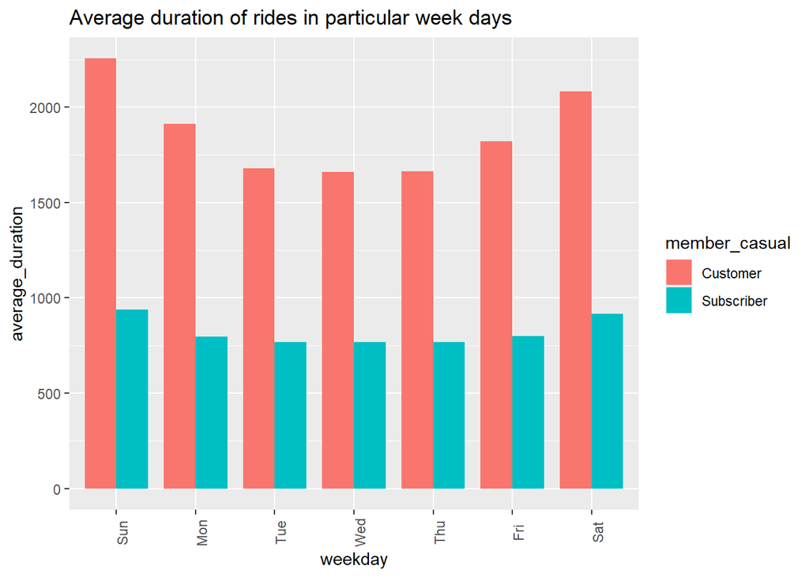

```r
#plotting data --memmbership v/s day wise
trips_v2 %>%
  mutate(weekday = wday(started_at, label = TRUE)) %>%
  group_by(weekday,member_casual) %>%
  summarise(number_of_rides = n(), average_duration = mean(ride_length)) %>%
  arrange(member_casual, weekday) %>%
  ggplot(aes(x = weekday, y = average_duration, fill = member_casual)) +
  geom_col(position = "dodge", width = 0.8) +
 theme(axis.text.x = element_text(angle = 90)) +
  ggtitle("Average duration of rides in particular week days")
```

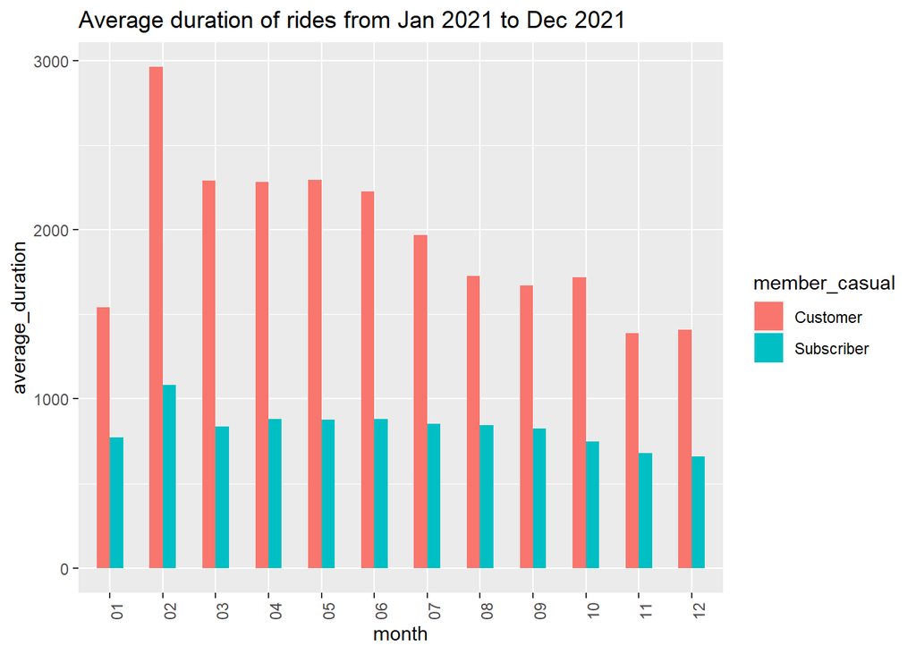

```r
#plotting monthly wise--month v/s membership
trips_v2 %>%
  group_by(month, member_casual) %>%
  summarise(number_of_rides = n(), average_duration = mean(ride_length)) %>%
  arrange(month, member_casual) %>%
  ggplot(aes(x = month, y = average_duration, fill = member_casual)) +
  geom_col(position = "dodge", width = 0.5) +
  theme(axis.text.x = element_text(angle = 90)) +
  ggtitle("Average duration of rides from Jan 2021 to Dec 2021")
```

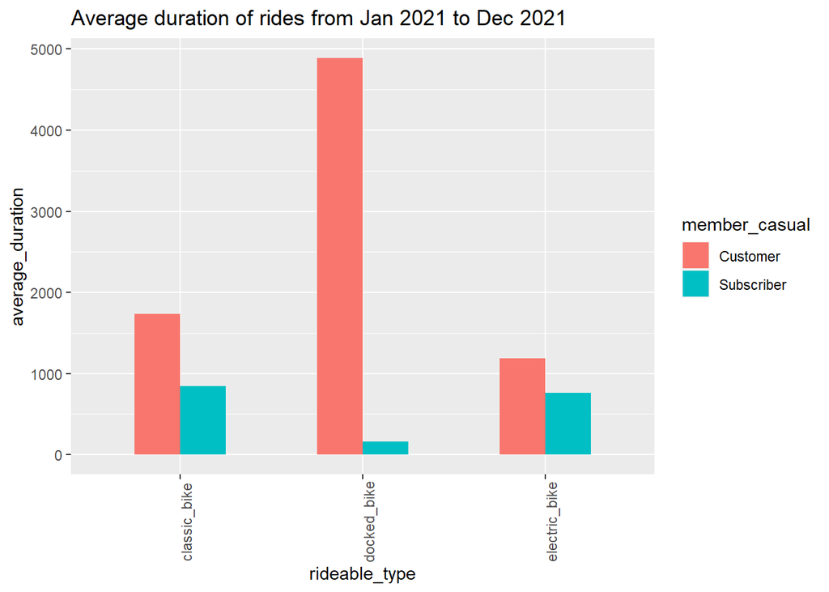

```r
#plotting with respect to ridertype
trips_v2 %>%
  group_by(rideable_type, member_casual) %>%
  summarise(number_of_rides = n(), average_duration = mean(ride_length)) %>%
  arrange(rideable_type, member_casual) %>%
  ggplot(aes(x = rideable_type, y = average_duration, fill = member_casual)) +
  geom_col(position = "dodge", width = 0.5) +
  theme(axis.text.x = element_text(angle = 90)) +
  ggtitle("Average duration of rides from Jan 2021 to Dec 2021")
```

```r
counts <- aggregate(trips_v2$ride_length ~ trips_v2$member_casual +
                      trips_v2$day_of_week, FUN = mean)
```

```r
counts
```

```
##    trips_v2$member_casual trips_v2$day_of_week trips_v2$ride_length
## 1                Customer               Friday            1820.9160
## 2              Subscriber               Friday             799.4950
## 3                Customer               Monday            1912.5269
## 4              Subscriber               Monday             794.8517
## 5                Customer             Saturday            2082.3740
## 6              Subscriber             Saturday             915.8742
## 7                Customer               Sunday            2253.9949
## 8              Subscriber               Sunday             939.4763
## 9                Customer             Thursday            1662.1955
## 10             Subscriber             Thursday             766.5710
## 11               Customer              Tuesday            1678.3396
## 12             Subscriber              Tuesday             767.2874
## 13               Customer            Wednesday            1659.4383
## 14             Subscriber            Wednesday             769.1496
```